# HW2 STATS506

Author

Ruixuan Deng

This is the link to [my repo](https://github.com/luckyeric320/STATS_506.git).

## Problem 1 - Dice Game

### a. b. c.

```r
#' Simulating Dice Game using for Loop
#'
#' @param n The number of dice rolls
#' @return The total winnings.
#' @examples
#' play_dice_loop(10)
#' play_dice_loop(100)
play_dice_loop <- function(n){
  total_winnings <- 0
  for (i in 1:n){
    total_winnings <- total_winnings - 2 # cost 2 dollars each time

    roll <- sample(1:6,1)
    if (roll == 3 || roll == 5){
        total_winnings <- total_winnings + 2*roll
    }
  }
  return(total_winnings)
}

set.seed(42)
play_dice_loop(3)
```

```
[1] 4
```

```r
play_dice_loop(3000)
```

```
[1] 1978
```

```r
#' Simulating Dice Game using Vectorized Functions
#'
#' @param n The number of dice rolls
#' @return The total winnings.
#' @examples
#' play_dice_vector(10)
#' play_dice_vector(100)
play_dice_vector <- function(n){
  rolls <- sample(1:6,n,replace = TRUE) # Sample the rolls
  winnings <- ifelse(rolls==3|rolls==5, 2*rolls,0)
  return(sum(winnings)-2*n) # Pay the cost for each roll
}

set.seed(42)
play_dice_vector(3)
```

```
[1] 4
```

```r
play_dice_vector(3000)
```

```
[1] 1978
```

```r
#' Simulating Dice Game using Table
#'
#' @param n The number of dice rolls
#' @return The total winnings.
#' @examples
#' play_dice_table(10)
#' play_dice_table(100)
play_dice_table <- function(n){
  rolls <- sample(1:6,n,replace = TRUE) # Sample the rolls
  rolls_factor <- factor(rolls,levels=1:6) # Setting the factor to prevent missing values
  rolls_table <- as.numeric(table(rolls_factor))
  total_winnings <- (rolls_table[3] * 6) + (rolls_table[5] * 10) - 2*n
  return(total_winnings)
}

set.seed(42)
play_dice_table(3)
```

```
[1] 4
```

```r
play_dice_table(3000)
```

```
[1] 1978
```

```r
#' Simulating Dice Game using apply
#'
#' @param n The number of dice rolls
#' @return The total winnings.
#' @examples
#' play_dice_apply(10)
#' play_dice_apply(100)
play_dice_apply <- function(n){
  rolls <- sample(1:6,n,replace = TRUE) # Sample the rolls
  winnings <- sapply(rolls, function(roll){
    if (roll == 3|roll ==5 ){
      return(2*roll)
    } else{
      return(0)
    }
  })
  return(sum(winnings)- 2*n)
}

set.seed(42)
play_dice_apply(3)
```

```
[1] 4
```

```r
play_dice_apply(3000)
```

```
[1] 1978
```

As we can see these 4 functions have the same results.

### d.

```r
library(microbenchmark)
mb <- microbenchmark(
  loop = play_dice_loop(1000),
  vectorized = play_dice_vector(1000),
  table = play_dice_table(1000),
  apply = play_dice_apply(1000)
)
print(mb)
```

```
Unit: microseconds
       expr    min      lq     mean  median      uq     max neval
       loop 4089.6 4696.15 5214.030 4795.65 5028.35 12501.8   100
 vectorized   94.5  115.90  132.789  126.35  145.90   226.2   100
      table  121.8  186.35  212.278  217.85  239.05   391.7   100
      apply  702.9  721.95  814.674  738.20  773.25  4127.0   100
```

```r
mb_1 <- microbenchmark(
  loop = play_dice_loop(100000),
  vectorized = play_dice_vector(100000),
  table = play_dice_table(100000),
  apply = play_dice_apply(100000)
)
print(mb_1)
```

```
Unit: milliseconds
       expr      min        lq      mean    median        uq      max neval
       loop 432.6158 471.92295 513.21065 491.13945 539.65160 714.2910   100
 vectorized   8.3297   9.93450  10.22075  10.16715  10.45365  13.9154   100
      table   8.9172  10.14740  10.79835  10.40955  10.87985  19.0863   100
      apply  76.5400  86.13975 105.25084  97.33290 113.73250 250.3570   100
```

From the results we can see that vectorized version is the fastest followed by table, as they both are real vectorized functions. Apply-based function is slower as it implements an implicit loop, and the loop-based version is the slowest.

### e.

```r
n_simulations <- 10000
n_rolls <- 1000

winnings <- replicate(n_simulations, play_dice_vector(n_rolls))
mean_winnings <- mean(winnings)


mean_winnings
```

```
[1] 667.808
```

We see from the result that this game is not fair. The player has a positive gain. This is consistent with the expectation total winnings.

## Problem 2 - Linear Regression

### a.

```r
library(ggplot2)
library(dplyr)
cars_data <- read.csv("cars.csv")
```

```r
# Rename the columns

cars_data <- cars_data %>%
  rename(
    Height = Dimensions.Height,
    Length = Dimensions.Length,
    Width = Dimensions.Width,
    Driverline = Engine.Information.Driveline,
    Engine_Type = Engine.Information.Engine.Type,
    Hybrid = Engine.Information.Hybrid,
    Num_Forward_Gear = Engine.Information.Number.of.Forward.Gears,
    Transimission = Engine.Information.Transmission,
    City_mpg = Fuel.Information.City.mpg,
    Fuel_Type = Fuel.Information.Fuel.Type,
    Highway_mpg = Fuel.Information.Highway.mpg,
    Classification = Identification.Classification,
    ID = Identification.ID,
    Make = Identification.Make,
    Model_Year = Identification.Model.Year,
    Year = Identification.Year,
    Horsepower = Engine.Information.Engine.Statistics.Horsepower,
    Torque = Engine.Information.Engine.Statistics.Torque
  )
```

### b.

```r
gasoline_data <- cars_data %>% filter(Fuel_Type == "Gasoline")
```

### c.

```r
summary(gasoline_data$Highway_mpg)
```

```
   Min. 1st Qu.  Median    Mean 3rd Qu.    Max.
  13.00   21.00   25.00   24.97   28.00  223.00
```

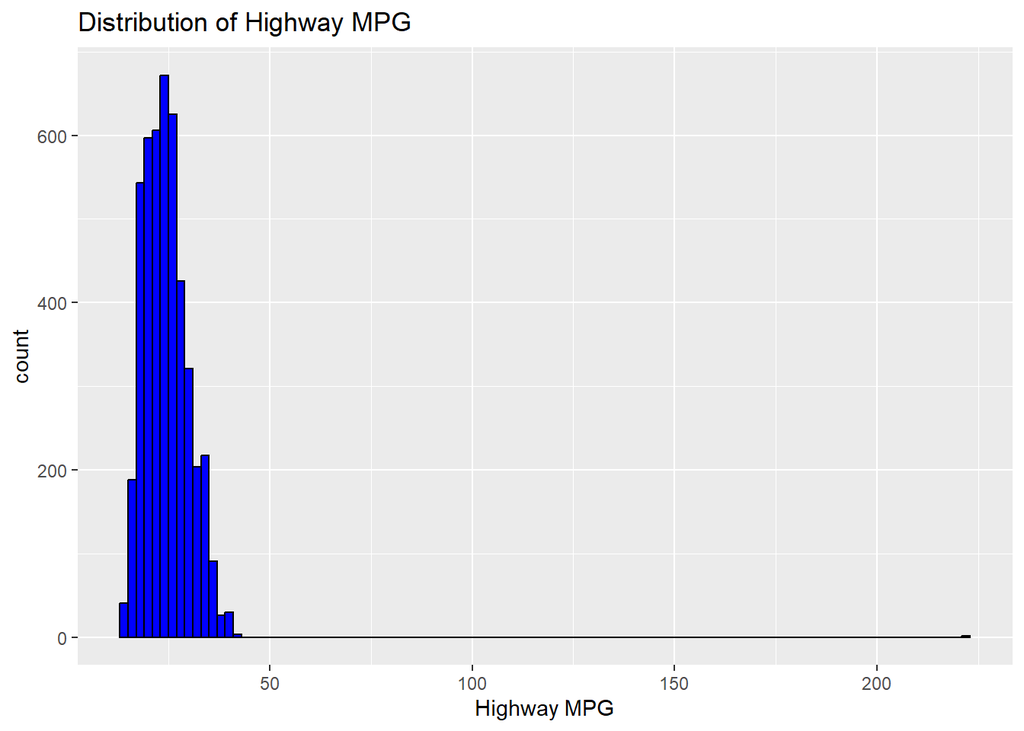

```r
ggplot(gasoline_data, aes(x = Highway_mpg)) +
  geom_histogram(binwidth = 2, fill = "blue", color = "black") +
  labs(title = "Distribution of Highway MPG", x = "Highway MPG")
```

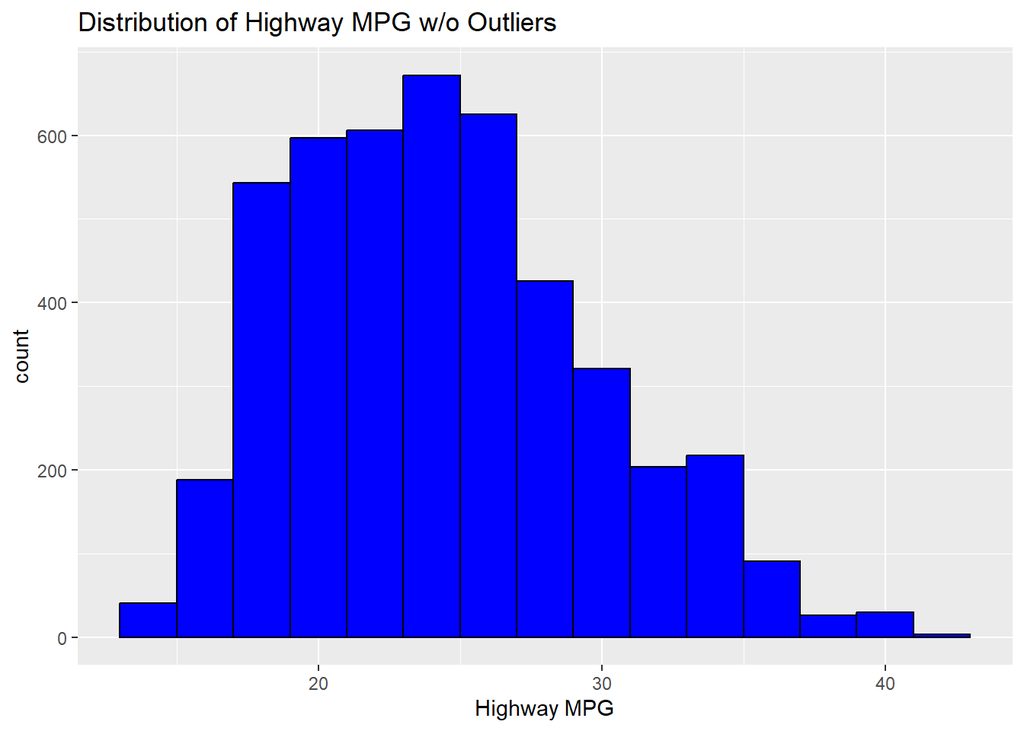

```r
ggplot(gasoline_data[gasoline_data$Highway_mpg < 200,], aes(x = Highway_mpg)) +
  geom_histogram(binwidth = 2, fill = "blue", color = "black") +
  labs(title = "Distribution of Highway MPG w/o Outliers", x = "Highway MPG")
```

It turns out that after eliminating the outlier, the skewness of the distribution is not extreme so we may not apply any transformation here.

### d.

```r
# Eliminate outliers
gasoline_data <- gasoline_data[gasoline_data$Highway_mpg < 200,]
gasoline_data$Year <-as.factor(gasoline_data$Year)

model <- lm(Highway_mpg ~ Torque + Horsepower + Length + Width + Height + Year, data = gasoline_data)

summary(model)
```

```
Call:
lm(formula = Highway_mpg ~ Torque + Horsepower + Length + Width +
    Height + Year, data = gasoline_data)

Residuals:
     Min       1Q   Median       3Q      Max
-10.9695  -2.4981  -0.3671   2.4164  19.8079

Coefficients:
              Estimate Std. Error t value Pr(>|t|)
(Intercept) 32.4107371  0.5486291  59.076   <2e-16 ***
Torque      -0.0517480  0.0016727 -30.937   <2e-16 ***
Horsepower   0.0171254  0.0017290   9.905   <2e-16 ***
Length       0.0011433  0.0006710   1.704   0.0885 .
Width       -0.0008147  0.0006867  -1.186   0.2356
Height       0.0104613  0.0008555  12.228   <2e-16 ***
Year2010    -0.4497677  0.5138721  -0.875   0.3815
Year2011     0.0709912  0.5130245   0.138   0.8899
Year2012     1.2925749  0.5170481   2.500   0.0125 *
---
Signif. codes:  0 '***' 0.001 '**' 0.01 '*' 0.05 '.' 0.1 ' ' 1

Residual standard error: 3.494 on 4581 degrees of freedom
Multiple R-squared:  0.5626,    Adjusted R-squared:  0.5618
F-statistic: 736.5 on 8 and 4581 DF,  p-value: < 2.2e-16
```

The regression result demonstrates a highly significant relation between torque and highway mpg, i.e., increasing torque by 1 lb/ft will lead to a decrease of about 0.0517 miles-per-gallon for highway driving.

### e.

```r
interaction_model <- lm(Highway_mpg ~ Torque*Horsepower+Length+Height+Width+Year, data = gasoline_data)

summary(interaction_model)
```

```
Call:
lm(formula = Highway_mpg ~ Torque * Horsepower + Length + Height +
    Width + Year, data = gasoline_data)

Residuals:
     Min       1Q   Median       3Q      Max
-11.2605  -2.2128  -0.2145   2.0901  21.6514

Coefficients:
                    Estimate Std. Error t value Pr(>|t|)
(Intercept)        4.247e+01  5.706e-01  74.436  < 2e-16 ***
Torque            -8.766e-02  1.823e-03 -48.090  < 2e-16 ***
Horsepower        -1.644e-02  1.827e-03  -9.000  < 2e-16 ***
Length             1.189e-03  5.985e-04   1.987  0.04700 *
Height             7.061e-03  7.696e-04   9.175  < 2e-16 ***
Width             -1.666e-03  6.131e-04  -2.717  0.00661 **
Year2010          -5.604e-01  4.584e-01  -1.222  0.22162
Year2011          -2.967e-02  4.577e-01  -0.065  0.94832
Year2012           1.185e+00  4.613e-01   2.569  0.01024 *
Torque:Horsepower  1.142e-04  3.330e-06  34.301  < 2e-16 ***
---
Signif. codes:  0 '***' 0.001 '**' 0.01 '*' 0.05 '.' 0.1 ' ' 1

Residual standard error: 3.117 on 4580 degrees of freedom
Multiple R-squared:  0.652, Adjusted R-squared:  0.6513
F-statistic: 953.3 on 9 and 4580 DF,  p-value: < 2.2e-16
```

```r
summary(gasoline_data$Horsepower)
```

```
   Min. 1st Qu.  Median    Mean 3rd Qu.    Max.
  100.0   185.0   263.0   267.5   317.0   638.0
```

The reasonable values of horsepower is chosen to be the 1st, 2nd and 3rd quantile.

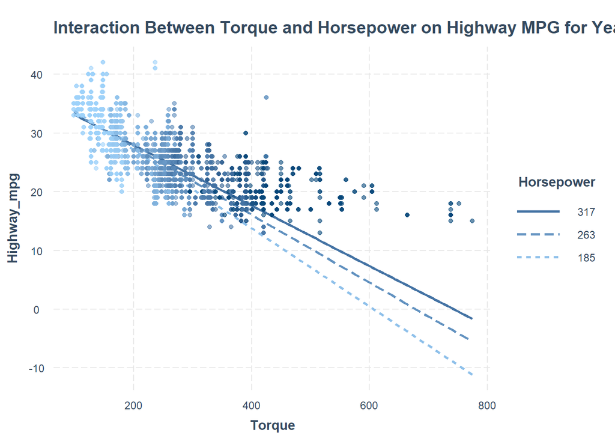

```r
library(interactions)
interact_plot(
  interaction_model,
  pred = Torque,
  modx = Horsepower,
  plot.points = TRUE,
  modx.values = c(185, 263, 317),
  main.title = "Interaction Between Torque and Horsepower on Highway MPG for Year 2011"
)
```

### f.

```r
# Create Design Matrix
X <- model.matrix(~Torque + Horsepower + Length + Width +
    Height + Year, data = gasoline_data)

Y <- gasoline_data$Highway_mpg

# Solve the equation
Beta_hat <-  solve(t(X) %*% X) %*% t(X) %*% Y
```

```r
print(Beta_hat)
```

```
                     [,1]
(Intercept) 32.4107371447
Torque      -0.0517480111
Horsepower   0.0171253987
Length       0.0011433004
Width       -0.0008146917
Height       0.0104613453
Year2010    -0.4497677480
Year2011     0.0709911939
Year2012     1.2925748832
```

```r
print(coef(model))
```

```
  (Intercept)        Torque    Horsepower        Length         Width
32.4107371447 -0.0517480111  0.0171253987  0.0011433004 -0.0008146917
       Height      Year2010      Year2011      Year2012
 0.0104613453 -0.4497677480  0.0709911939  1.2925748832
```

We can see the results are the same.